# Word Cloud of CSO Strategy Statment 2012-2014

It is possible to read in a pdf file from the internet and convert it in to text format. You can then use this to create conduct text mining e.g. create a word cloud.

In these examples the CSO Strategy Statement is taken from the cSO website and summarised as a word cloud.

```r
# download pdftotxt from ftp://ftp.foolabs.com/pub/xpdf/xpdfbin-win-3.03.zip and extract to your program files folder

# here is the CSO Ctrategy Statmenent 2012-2014 pdf for mining
url <- "http://www.cso.ie/en/media/csoie/releasespublications/documents/corporatepublications/StatementofStrategy201214.pdf"
dest <- tempfile(fileext = ".pdf")
download.file(url, dest, mode = "wb")
# set path to pdftotxt.exe and convert pdf to text
exe <- "C:\\Program Files (x86)\\xpdfbin-win-3.04\\bin64\\pdftotext.exe"
system(paste("\"", exe, "\" \"", dest, "\"", sep = ""), wait = F)
# get txt-file name and open it
filetxt <- sub(".pdf", ".txt", dest)
shell.exec(filetxt)
# do something with it, i.e. a simple word cloud
library(tm)
library(wordcloud)
library(Rstem)
library(stringr)
txt <- readLines(filetxt) # don't mind warning..
txt <- tolower(txt)
txt <- removeWords(txt, c("\\f", stopwords()))
corpus <- Corpus(VectorSource(txt))
corpus <- tm_map(corpus, removePunctuation)
tdm <- TermDocumentMatrix(corpus)
m <- as.matrix(tdm)
d <- data.frame(freq = sort(rowSums(m), decreasing = TRUE))
# Stem words
d$stem <- wordStem(row.names(d), language = "english")
# and put words to column, otherwise they would be lost when aggregating
d$word <- row.names(d)
# remove web address (very long string):
d <- d[nchar(row.names(d)) < 20, ]
# aggregate freqeuncy by word stem and
# keep first words..
agg_freq <- aggregate(freq ~ stem, data = d, sum)
agg_word <- aggregate(word ~ stem, data = d, function(x) x[1])
d <- cbind(freq = agg_freq[, 2], agg_word)
# sort by frequency
d <- d[order(d$freq, decreasing = T), ]
# print wordcloud:
wordcloud(d$word, d$word,colors = brewer.pal(d$freq, "Dark2"))
# remove temp files
file.remove(dir(tempdir(), full.name=T)) # remove files
```

Here is the first word cloud:

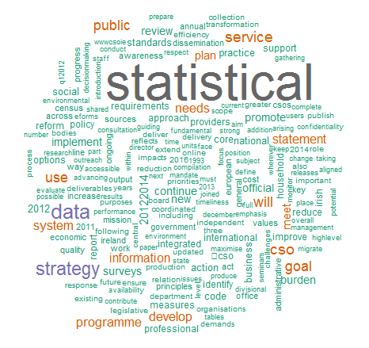

As mentioned above this word cloud is a summary of the CSO Strategy Statement, however, it needs to be tidied up. In its current form the small number of keywords which appear more frequently than others tells a particular tale. As these words do appear more frequently in the document they dominate in the visual summary. However, these keywords are like outliers in that in a word cloud they obscure the role that other keywords have to play in the document. Although the full text of the document has its own merits,we may get a better idea of what’s going inside the strategy statement if we remove of the principal keywords. There are also digits in the word cloud which do not add any value to the summary.

Let’s remove the three most common words: statistical, data and strategy. We can see these are the three most commonly occurring words from the word cloud as they are simply bigger than the other words.

However for a more formal approach we can do this (because d is ordered by frequency in decreasing values- see the code above):

```r
d$word[1:3]
[1] "statistical" "data"        "strategy"
```

We should also remove the digits and unnecessary puntuation

```r
txt <- removeWords(txt, c("\\f", stopwords()))
txt <- removeWords(txt, c("statistical", "data","strategy", stopwords()))
#txt<-gsub("\t\n\r\v\f", "", txt, fixed = TRUE)
txt<-gsub("cso", "cso", txt, fixed = TRUE)
txt <- removeWords(txt, stopwords("english"))
txt <- removeNumbers(txt)
txt <- removePunctuation(txt)
corpus <- Corpus(VectorSource(txt))
tdm <- TermDocumentMatrix(corpus)
m <- as.matrix(tdm)
d <- data.frame(freq = sort(rowSums(m), decreasing = TRUE))
# Stem words
d$stem <- wordStem(row.names(d), language = "english")
# and put words to column, otherwise they would be lost when aggregating
d$word <- row.names(d)
# remove web address (very long string):
d <- d[nchar(row.names(d)) < 8, ]
# aggregate freqeuncy by word stem and
# keep first words.
agg_freq <- aggregate(freq ~ stem, data = d, sum)
agg_word <- aggregate(word ~ stem, data = d, function(x) x[1])
d <- cbind(freq = agg_freq[, 2], agg_word)
# sort by frequency
d <- d[order(d$freq, decreasing = T), ]
# print wordcloud:
wordcloud(d$word, d$freq,scale=c(3,.5),min.freq=3, colors = brewer.pal(8, "Dark2"))
```

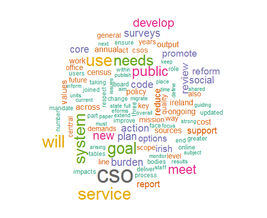

idea based on r code from: http://stackoverflow.com/questions/20721227/executing-a-script-on-a-list-of-files-in-a-directory-in-r https://georeferenced.wordpress.com/2013/01/15/rwordcloud/ http://stackoverflow.com/questions/18446408/adding-stopwords-in-r-tm http://stackoverflow.com/questions/5992082/how-to-remove-all-whitespace-from-a-string